# Assignment12

## Portfolio assignment 12

30 min: Perform a bivariate analysis on at least 3 combinations of a numerical column with a categorical column in the dataset that you chose in portfolio assignment 4. Use .groupby('columnname').mean() to calculate the means. Is there a difference between categories? Then use seaborn barplots to check if there is a statistically significant difference.

```python
import pandas as pd
import seaborn as sns
```

```python
penguins = sns.load_dataset("penguins")
PremStats = pd.read_csv("../data/EPL_20_21.csv")
```

```python
PremStats['Position'] = PremStats['Position'].replace(['MF,DF', 'MF,FW'],'MF')
PremStats['Position'] = PremStats['Position'].replace(['FW,MF', 'FW,DF'],'FW')
PremStats['Position'] = PremStats['Position'].replace(['DF,MF', 'DF,FW'],'DF')
PremStats.head()
```

|  | Name | Club | Nationality | Position | Age | Matches | Starts | Mins | Goals | Assists | Passes_Attempted | Perc_Passes_Completed | Penalty_Goals | Penalty_Attempted | xG | xA | Yellow_Cards | Red_Cards |
| --- | --- | --- | --- | --- | --- | --- | --- | --- | --- | --- | --- | --- | --- | --- | --- | --- | --- | --- |
| 0 | Mason Mount | Chelsea | ENG | MF | 21 | 36 | 32 | 2890 | 6 | 5 | 1881 | 82.3 | 1 | 1 | 0.21 | 0.24 | 2 | 0 |
| 1 | Edouard Mendy | Chelsea | SEN | GK | 28 | 31 | 31 | 2745 | 0 | 0 | 1007 | 84.6 | 0 | 0 | 0.00 | 0.00 | 2 | 0 |
| 2 | Timo Werner | Chelsea | GER | FW | 24 | 35 | 29 | 2602 | 6 | 8 | 826 | 77.2 | 0 | 0 | 0.41 | 0.21 | 2 | 0 |
| 3 | Ben Chilwell | Chelsea | ENG | DF | 23 | 27 | 27 | 2286 | 3 | 5 | 1806 | 78.6 | 0 | 0 | 0.10 | 0.11 | 3 | 0 |
| 4 | Reece James | Chelsea | ENG | DF | 20 | 32 | 25 | 2373 | 1 | 2 | 1987 | 85.0 | 0 | 0 | 0.06 | 0.12 | 3 | 0 |

Ik heb hier boven de posities aangepast om deze representatiever te maken en dus hun primaire positie te nemen i.p.v meerderen

```python
PremStats.groupby(['Position']).mean()
```

| Position | Age | Matches | Starts | Mins | Goals | Assists | Passes_Attempted | Perc_Passes_Completed | Penalty_Goals | Penalty_Attempted | xG | xA | Yellow_Cards | Red_Cards |
| --- | --- | --- | --- | --- | --- | --- | --- | --- | --- | --- | --- | --- | --- | --- |
| DF | 25.713568 | 18.236181 | 16.467337 | 1473.723618 | 0.718593 | 0.783920 | 890.814070 | 80.262312 | 0.005025 | 0.005025 | 0.045075 | 0.041658 | 2.452261 | 0.135678 |
| FW | 24.858209 | 19.895522 | 13.455224 | 1223.455224 | 4.283582 | 2.082090 | 409.141791 | 73.325373 | 0.417910 | 0.492537 | 0.263657 | 0.121269 | 1.298507 | 0.067164 |
| GK | 28.190476 | 18.214286 | 18.095238 | 1628.500000 | 0.023810 | 0.047619 | 568.547619 | 69.119048 | 0.000000 | 0.000000 | 0.000000 | 0.001905 | 0.738095 | 0.023810 |
| MF | 25.057325 | 21.229299 | 16.050955 | 1434.885350 | 1.707006 | 1.579618 | 801.700637 | 80.901274 | 0.286624 | 0.369427 | 0.101720 | 0.089363 | 2.751592 | 0.070064 |

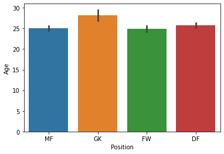

```python
sns.barplot(y="Age", x="Position", data=PremStats)
```

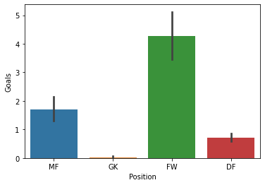

```python
sns.barplot(y="Goals", x="Position", data=PremStats)
```

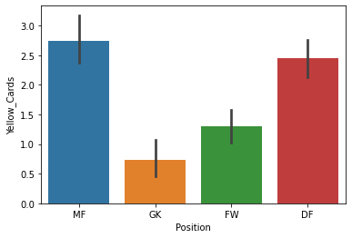

```python
sns.barplot(y="Yellow_Cards", x="Position", data=PremStats)
```

Bij de leeftijd zie je een licht verschil vooral bij de keepers die redelijk ouder zijn. Verdedigers ook licht maar niet heel veel.

De goals is er een duidelijk verschil tussen de aanvallers die er boven uit steken. Middevelders steken ook nog boven de verdedigers uit maar die zakken heel laag met de keepers nog veel lager.

Bij de gele kaarten is juist te zien dat middevelders en Verdedigers deze vooral veel hebben en ongeveer het zelfde aantal. Daarnaast een stuk minder kaarten voor aanvallers en keepers.